# Exploration of Data

Matthew Perrotta

5/10/2019

### Load Libraries

```r
library(tidyverse)
library(mgcv)
library(corrplot)
library(Hmisc)
library(caret)
library(PerformanceAnalytics)
library(car)
library(olsrr)
#library(MASS)
#library(raster)
```

READ: https://www.nature.com/articles/s41598-017-02560-z

### Import and clean data

Two datasets are created, `swk` for Sarawak and `sbh` for Sabah. Variables that are not needed are removed.

```r
swk = read.csv('./data/data_full_sar.csv') %>%
  group_by(district, year) %>%
  mutate(district_area =
           CropRainfed.total.area +
           Herbaceous.total.area +
           TreeShrub.total.area +
           MosCrop.total.area +
           MosNatural.total.area +
           BroadEvgClop.total.area +
           Shrub.total.area +
           ShrubEvg.total.area +
           SparseVeg.total.area +
           FloodFresh.total.area +
           FloodSalt.total.area +
           Urban.total.area +
           Water.total.area +
           CropIrrigate.total.area
         ) %>%
  ungroup() %>%
  group_by(district) %>%
  mutate(CropRainfed.prop = CropRainfed.total.area/district_area,
         Herbaceous.prop = Herbaceous.total.area/district_area,
         TreeShrub.prop = TreeShrub.total.area/district_area,
         MosCrop.prop = MosCrop.total.area/district_area,
         MosNatural.prop = MosNatural.total.area/district_area,
         BroadEvgClop.prop = BroadEvgClop.total.area/district_area,
         Shrub.prop = Shrub.total.area/district_area,
         ShrubEvg.prop = ShrubEvg.total.area/district_area,
         SparseVeg.prop = SparseVeg.total.area/district_area,
         FloodFresh.prop = FloodFresh.total.area/district_area,
         FloodSalt.prop = FloodSalt.total.area/district_area,
         Urban.prop = Urban.total.area/district_area,
         Water.prop = Water.total.area/district_area,
         CropIrrigate.prop = CropIrrigate.total.area/district_area) %>%
  janitor::clean_names() %>%
  ungroup() %>%
  select(-c('x',
            'population_year',
            'cases_year',
            'expected',
            'sd')) %>%
  rename('smr' = 'sir',
         'prec_mean' = 'mean',
         'cases' = 'case_number') %>%
  na.omit()


sbh = read.csv('./data/dataFull.csv') %>%
  group_by(District, Year) %>%
  mutate(district_area =
           CropRainfed.total.area +
           Herbaceous.total.area +
           TreeShrub.total.area +
           MosCrop.total.area +
           MosNatural.total.area +
           BroadEvgClop.total.area +
           Shrub.total.area +
           ShrubEvg.total.area +
           SparseVeg.total.area +
           FloodFresh.total.area +
           FloodSalt.total.area +
           Urban.total.area +
           Water.total.area +
           CropIrrigate.total.area +
           Grass.total.area +
           MosTreeHerb.total.area
         ) %>%
  ungroup() %>%
  group_by(District) %>%
  mutate(CropRainfed.prop = CropRainfed.total.area/district_area,
         Herbaceous.prop = Herbaceous.total.area/district_area,
         TreeShrub.prop = TreeShrub.total.area/district_area,
         MosCrop.prop = MosCrop.total.area/district_area,
         MosNatural.prop = MosNatural.total.area/district_area,
         BroadEvgClop.prop = BroadEvgClop.total.area/district_area,
         Shrub.prop = Shrub.total.area/district_area,
         ShrubEvg.prop = ShrubEvg.total.area/district_area,
         SparseVeg.prop = SparseVeg.total.area/district_area,
         FloodFresh.prop = FloodFresh.total.area/district_area,
         FloodSalt.prop = FloodSalt.total.area/district_area,
         Urban.prop = Urban.total.area/district_area,
         Water.prop = Water.total.area/district_area,
         CropIrrigate.prop = CropIrrigate.total.area/district_area,
         Grass.prop = Grass.total.area/district_area,
         MosTreeHerb.prop = MosTreeHerb.total.area/district_area) %>%
  janitor::clean_names() %>%
  ungroup() %>%
  select(-c('x',
            'disease',
            'number_deaths',
            'mortality_rates',
            'prevalence',
            'incidence_rate')) %>%
  rename('cases' = 'number_cases') %>%
  na.omit()
```

Observations with `NA` values were omitted from the data set

Land Cover variable discriptions:

- `crop_rainfed` - Cropland, rainfed
- `crop_irrigate` - Cropland, irrigated or post-flooding
- `mos_crop` - Mosaic cropland (>50%) / natural vegetation (tree, shrub, herbaceous cover)(<50%)
- `mos_natural` - Mosaic natural vegetation (tree, shrub, herbaceous cover) (>50%) / cropland (<50%)
- `mos_tree_herb` - Mosaic tree and shrub (>50%) / herbaceous cover (<50%)
- `herbaceous` - Herbaceous cover
- `tree_shrub` - Tree or shrub cover
- `broad_evg_clop` - Tree cover, broadleaved, evergreen, closed to open (>15%)
- `shrub` - Shrubland
- `shrub_evg` - Shrubland evergreen
- `sparse_veg` - Sparse vegetation (tree, shrub, herbaceous cover) (<15%)
- `flood_fresh` - Tree cover, flooded, fresh or brakish water
- `flood_salt` - Tree cover, flooded, saline water
- `grass` - Grassland
- `urban` - Urban areas
- `water` - Water bodies

The Sarawak dataset does not have the following variables:

- `grass_n_patches`
- `grass_patch_density`
- `grass_total_area`
- `grass_prop`
- `mos_tree_herb_n_patches`
- `mos_tree_herb_patch_density`
- `mos_tree_herb_total_area`
- `mos_tree_herb_prop`

Creating a variable for agriculture

```r
sbh = sbh %>%
  group_by(district, year) %>%
  mutate(agri_total_area = crop_rainfed_total_area +
           crop_irrigate_total_area +
           herbaceous_total_area +
           tree_shrub_total_area +
           mos_crop_total_area +
           mos_natural_total_area) %>%
  mutate(agri_prop = agri_total_area/district_area) %>%
  ungroup()

swk = swk %>%
  group_by(district, year) %>%
  mutate(agri_total_area = crop_rainfed_total_area +
           crop_irrigate_total_area +
           herbaceous_total_area +
           tree_shrub_total_area +
           mos_crop_total_area +
           mos_natural_total_area) %>%
  mutate(agri_prop = agri_total_area/district_area) %>%
  ungroup()
```

### Exploration of the Data

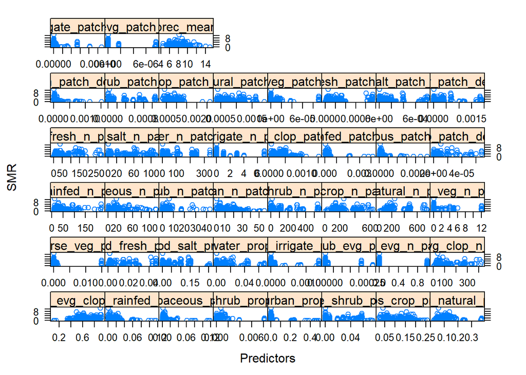

```r
sbh_sub = sbh %>%
  select(c("smr", "broad_evg_clop_prop", "crop_rainfed_prop", "herbaceous_prop", "shrub_prop", "urban_prop", "tree_shrub_prop", "mos_crop_prop", "mos_natural_prop", "sparse_veg_prop", "flood_fresh_prop", "flood_salt_prop", "water_prop", "crop_irrigate_prop", "shrub_evg_prop", "shrub_evg_n_patches", "broad_evg_clop_n_patches", "crop_rainfed_n_patches", "herbaceous_n_patches", "shrub_n_patches", "urban_n_patches", "tree_shrub_n_patches", "mos_crop_n_patches", "mos_natural_n_patches", "sparse_veg_n_patches", "flood_fresh_n_patches", "flood_salt_n_patches", "water_n_patches", "crop_irrigate_n_patches", "broad_evg_clop_patch_density","crop_rainfed_patch_density", "herbaceous_patch_density", "shrub_patch_density", "urban_patch_density", "tree_shrub_patch_density", "mos_crop_patch_density", "mos_natural_patch_density", "sparse_veg_patch_density", "flood_fresh_patch_density", "flood_salt_patch_density", "water_patch_density", "crop_irrigate_patch_density", "shrub_evg_patch_density", "prec_mean"))

swk_sub = swk %>%
  select(c("smr", "broad_evg_clop_prop", "crop_rainfed_prop", "herbaceous_prop", "shrub_prop", "urban_prop", "tree_shrub_prop", "mos_crop_prop", "mos_natural_prop", "sparse_veg_prop", "flood_fresh_prop", "flood_salt_prop", "water_prop", "crop_irrigate_prop", "shrub_evg_prop", "shrub_evg_n_patches", "broad_evg_clop_n_patches", "crop_rainfed_n_patches", "herbaceous_n_patches", "shrub_n_patches", "urban_n_patches", "tree_shrub_n_patches", "mos_crop_n_patches", "mos_natural_n_patches", "sparse_veg_n_patches", "flood_fresh_n_patches", "flood_salt_n_patches", "water_n_patches", "crop_irrigate_n_patches", "broad_evg_clop_patch_density","crop_rainfed_patch_density", "herbaceous_patch_density", "shrub_patch_density", "urban_patch_density", "tree_shrub_patch_density", "mos_crop_patch_density", "mos_natural_patch_density", "sparse_veg_patch_density", "flood_fresh_patch_density", "flood_salt_patch_density", "water_patch_density", "crop_irrigate_patch_density", "shrub_evg_patch_density", "prec_mean"))

sbh.x = model.matrix(smr~., sbh_sub, na.action = NULL)[,-1]
sbh.y = sbh_sub$smr

swk.x = model.matrix(smr~., swk_sub)[,-1]
swk.y = swk_sub$smr

featurePlot(sbh.x,
            sbh.y,
            plot = "scatter",
            labels = c("Predictors","SMR"),
            type = c('p'))
```

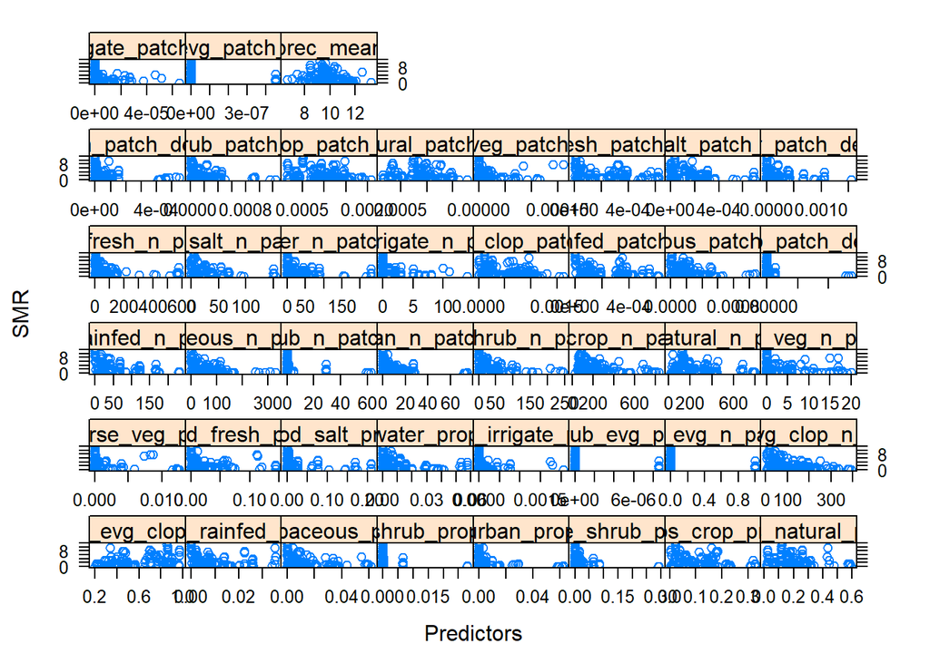

```r
featurePlot(swk.x,
            swk.y,
            plot = "scatter",
            labels = c("Predictors","SMR"),
            type = c('p'))
```

Distribution of SMR

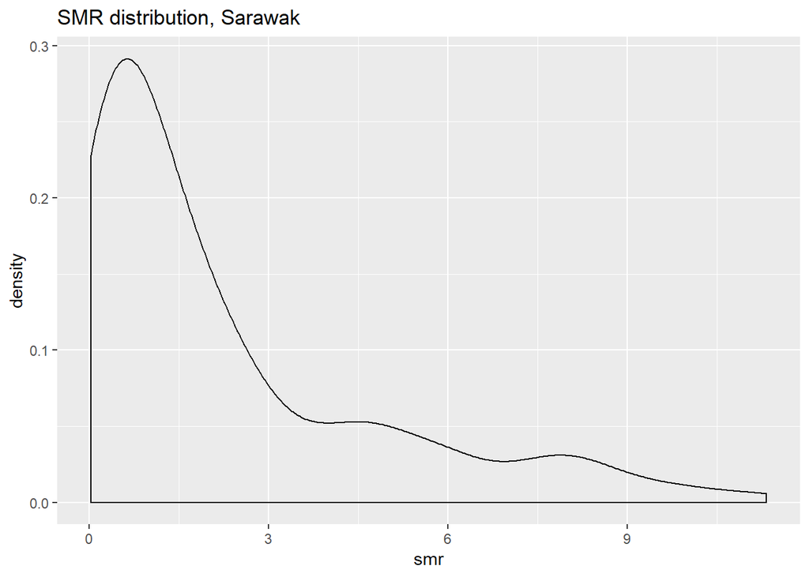

```r
ggplot(data = swk, aes(x = smr)) +
  geom_density() +
  labs(title = 'SMR distribution, Sarawak')
```

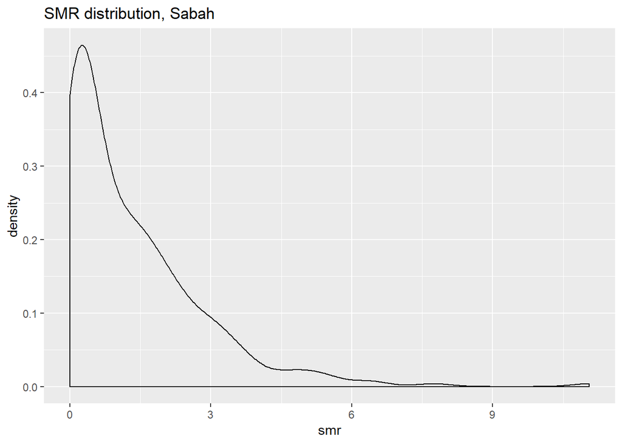

```r
ggplot(data = sbh, aes(x = smr)) +
  geom_density() +
  labs(title = 'SMR distribution, Sabah')
```

Distribution of cases

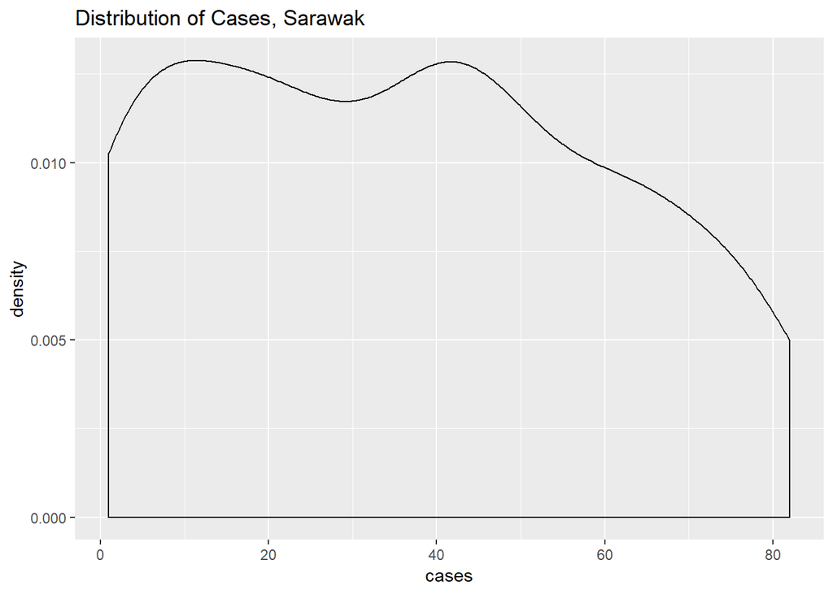

```r
ggplot(data = swk, aes(x = cases)) +
  geom_density() +
  labs(title = 'Distribution of Cases, Sarawak')
```

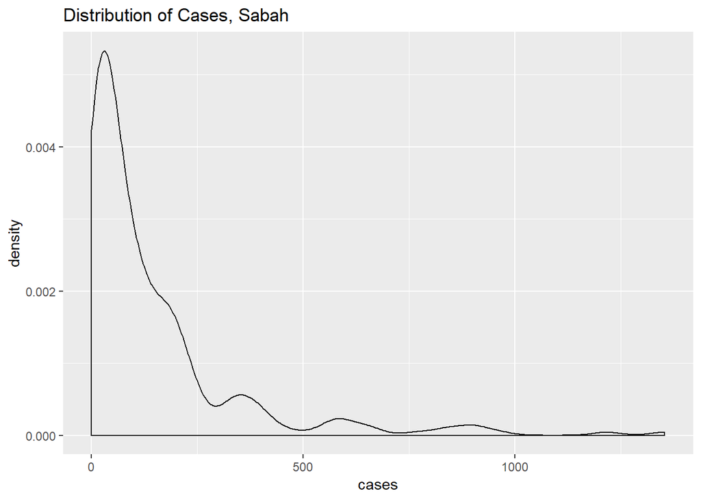

```r
ggplot(data = sbh, aes(x = cases)) +
  geom_density() +
  labs(title = 'Distribution of Cases, Sabah')
```

Cases overtime

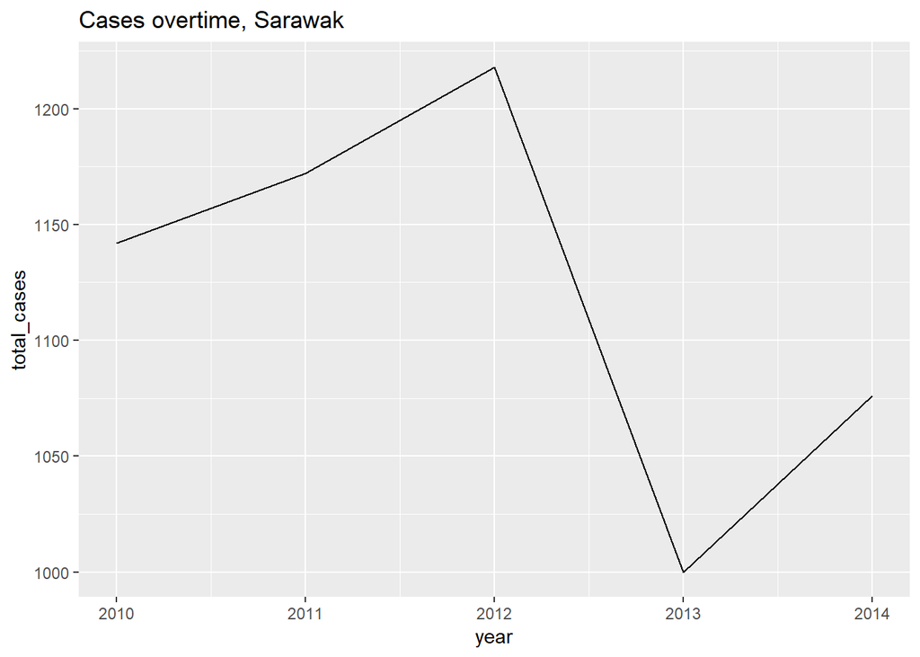

```r
swk %>%
  group_by(year) %>%
  mutate(total_cases = sum(cases)) %>%
  ggplot(aes(y = total_cases, x = year)) +
  geom_line() +
  labs(title = 'Cases overtime, Sarawak')
```

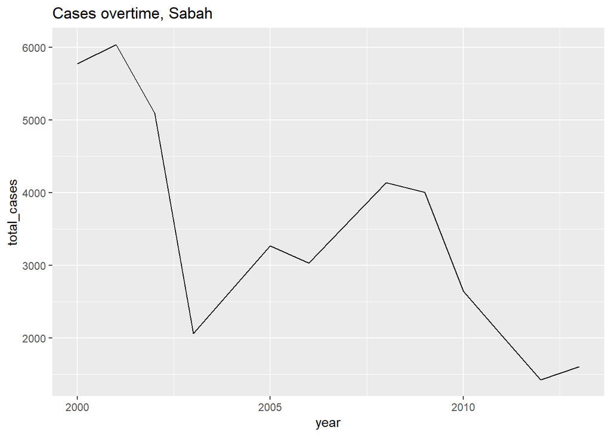

```r
sbh %>%
  group_by(year) %>%
  mutate(total_cases = sum(cases)) %>%
  ggplot(aes(y = total_cases, x = year)) +
  geom_line() +
  labs(title = 'Cases overtime, Sabah')
```

### Spaghetti Plots

SMR by District

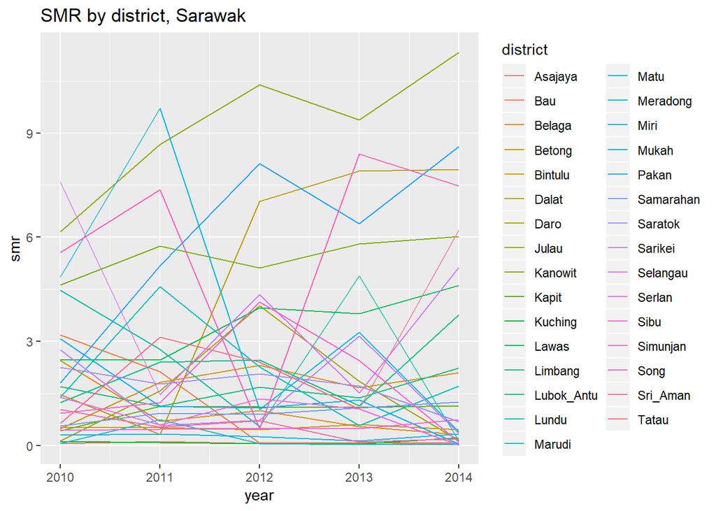

```r
swk %>%
  ggplot(aes(y = smr, x = year, color = district)) +
  geom_line() +
  labs(title = 'SMR by district, Sarawak')
```

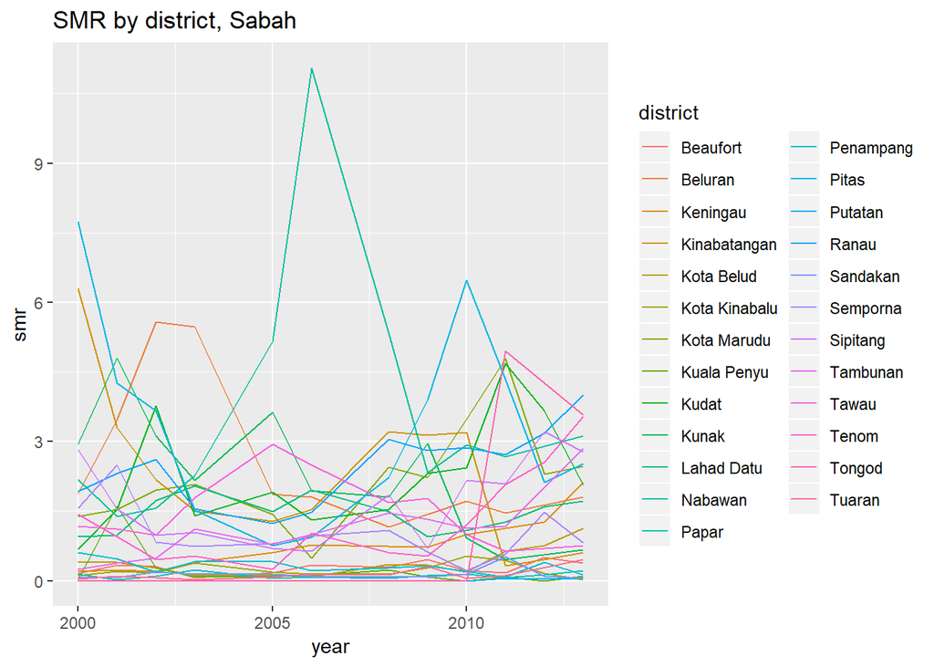

```r
sbh %>%
  ggplot(aes(y = smr, x = year, color = district)) +
  geom_line() +
  labs(title = 'SMR by district, Sabah')
```

Cases by district

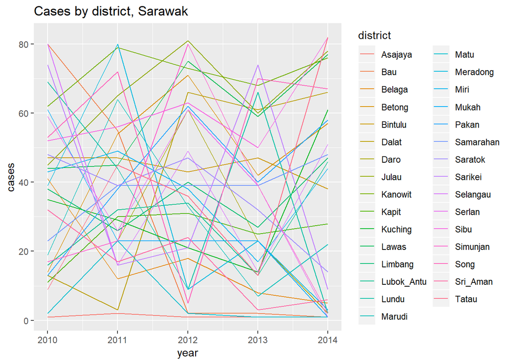

```r
swk %>%
  ggplot(aes(y = cases, x = year, color = district)) +
  geom_line() +
  labs(title = 'Cases by district, Sarawak')
```

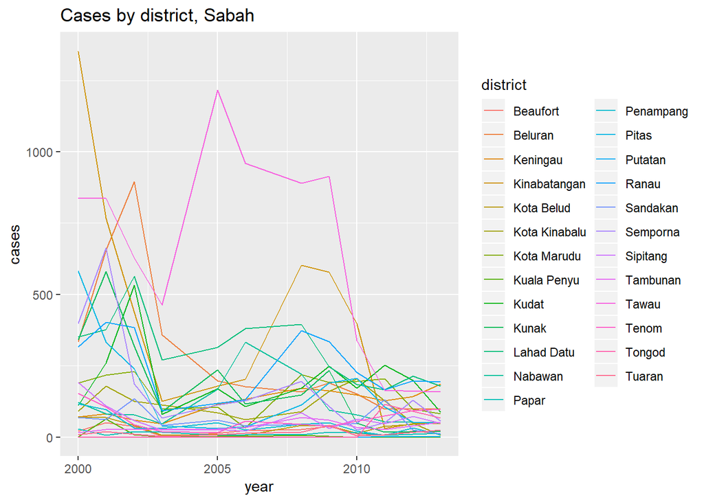

```r
sbh %>%
  ggplot(aes(y = cases, x = year, color = district)) +
  geom_line() +
  labs(title = 'Cases by district, Sabah')
```

Mean precipitation across districts of Sabah and Sarawak

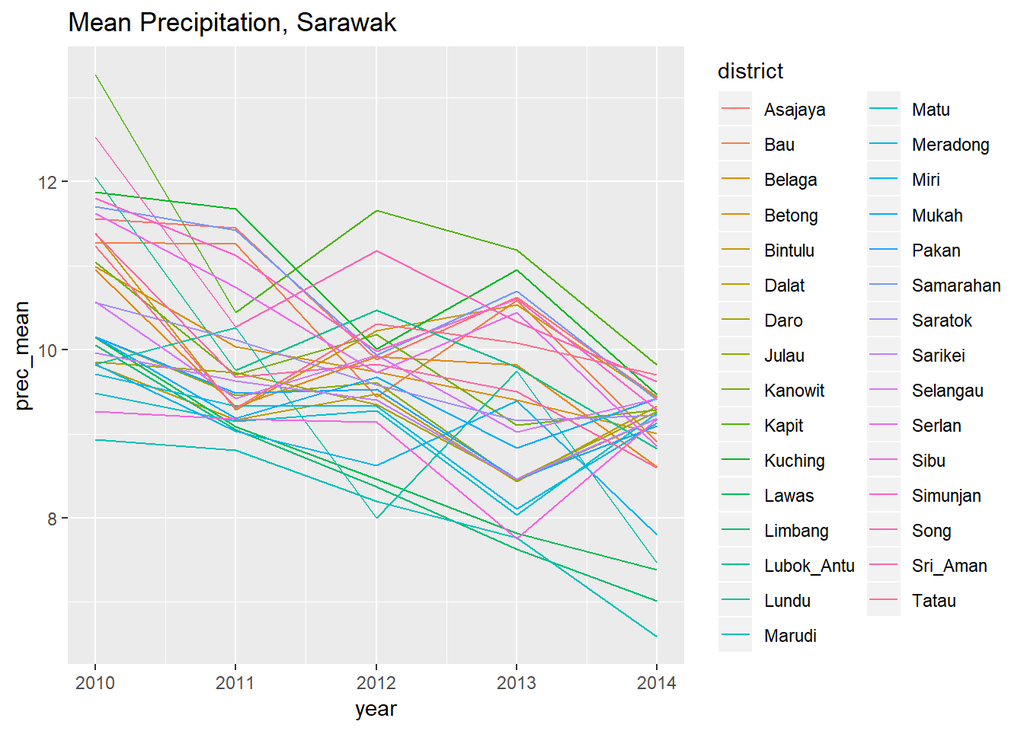

```r
ggplot(data = swk, aes(x = year, y = prec_mean, color = district)) +
  geom_line() +
  labs(title = 'Mean Precipitation, Sarawak')
```

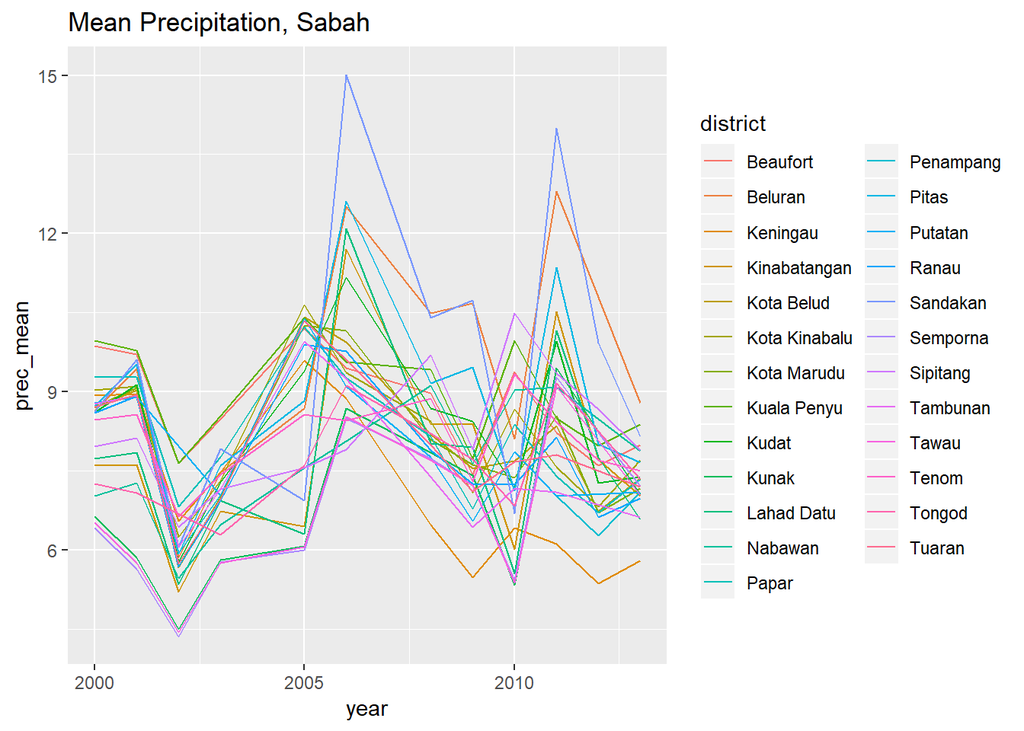

```r
ggplot(data = sbh, aes(x = year, y = prec_mean, color = district)) +
  geom_line() +
  labs(title = 'Mean Precipitation, Sabah')
```

Forest cover across districts, Sarawak and Sabah

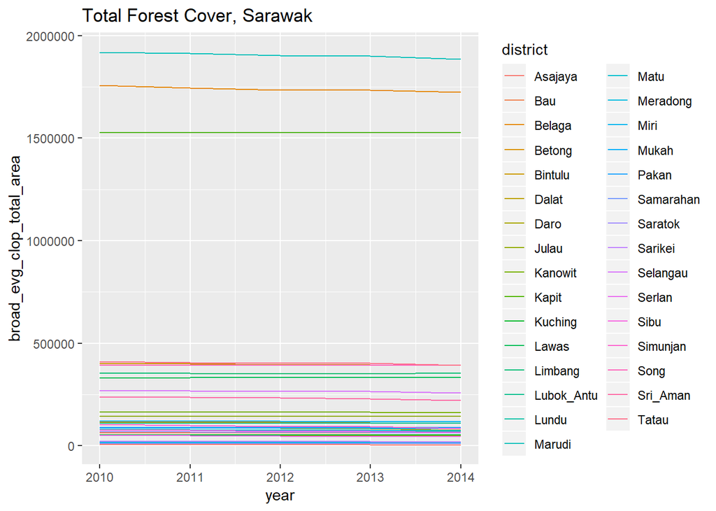

```r
#Total area
ggplot(data = swk, aes(x = year, y = broad_evg_clop_total_area, color = district)) +
  geom_line() +
  labs(title = 'Total Forest Cover, Sarawak')
```

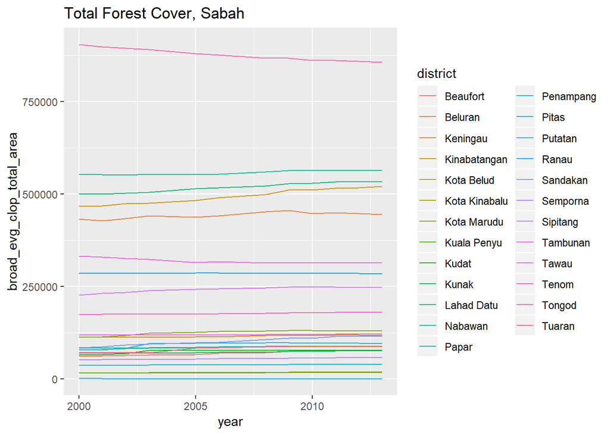

```r
ggplot(data = sbh, aes(x = year, y = broad_evg_clop_total_area, color = district)) +
  geom_line() +
  labs(title = 'Total Forest Cover, Sabah')
```

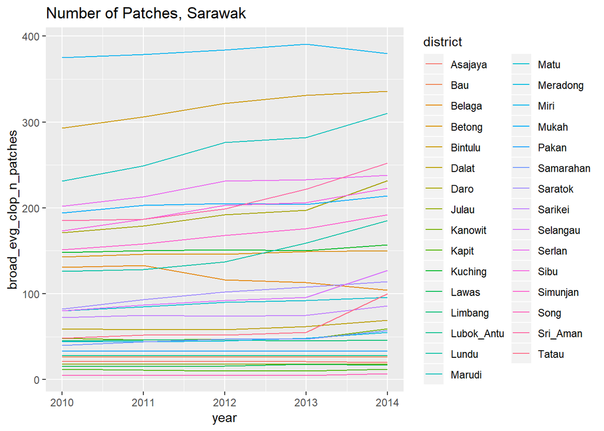

```r
#Number of patches
ggplot(data = swk, aes(x = year, y = broad_evg_clop_n_patches, color = district)) +
  geom_line() +
  labs(title = 'Number of Patches, Sarawak')
```

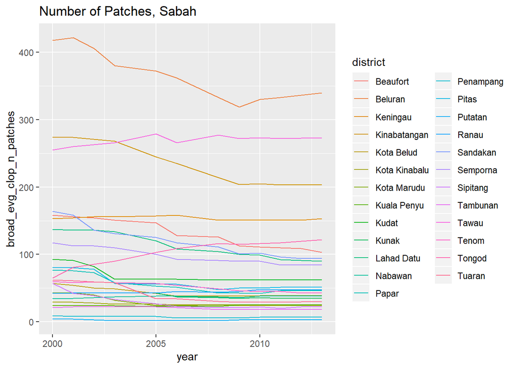

```r
ggplot(data = sbh, aes(x = year, y = broad_evg_clop_n_patches, color = district)) +
  geom_line() +
  labs(title = 'Number of Patches, Sabah')
```

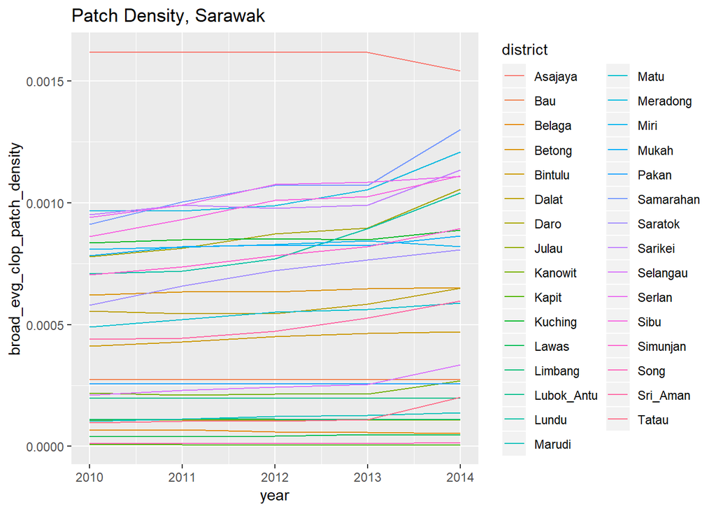

```r
#Patch density
ggplot(data = swk, aes(x = year, y = broad_evg_clop_patch_density, color = district)) +
  geom_line() +
  labs(title = 'Patch Density, Sarawak')
```

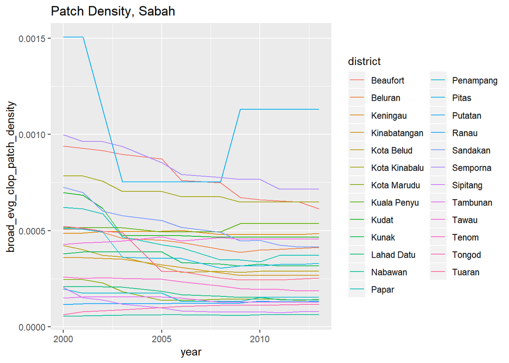

```r
ggplot(data = sbh, aes(x = year, y = broad_evg_clop_patch_density, color = district)) +
  geom_line() +
  labs(title = 'Patch Density, Sabah')
```

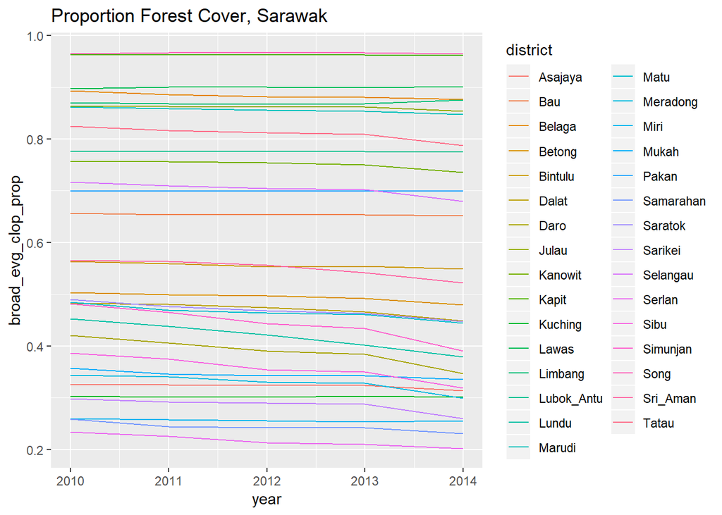

```r
#Patch density
ggplot(data = swk, aes(x = year, y = broad_evg_clop_prop, color = district)) +
  geom_line() +
  labs(title = 'Proportion Forest Cover, Sarawak')
```

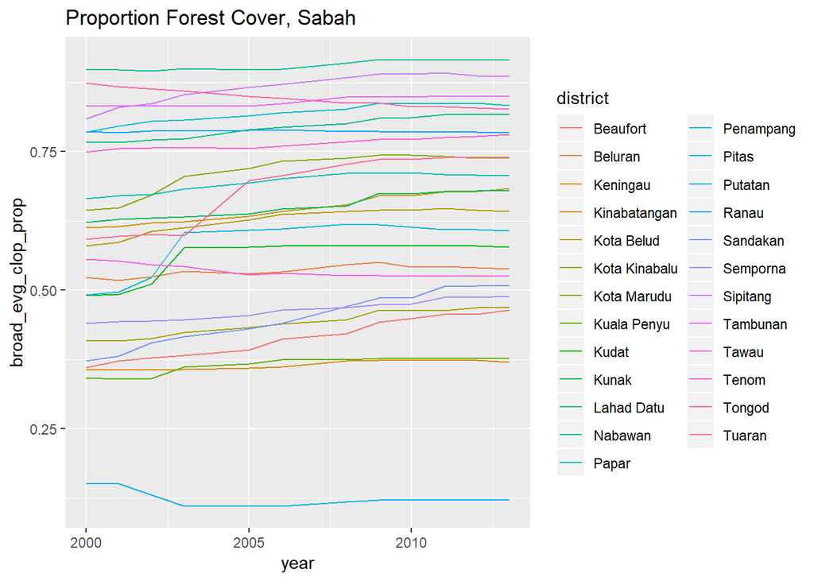

```r
ggplot(data = sbh, aes(x = year, y = broad_evg_clop_prop, color = district)) +
  geom_line() +
  labs(title = 'Proportion Forest Cover, Sabah')
```

Agricultural cover across districts, Sarawak and Sabah

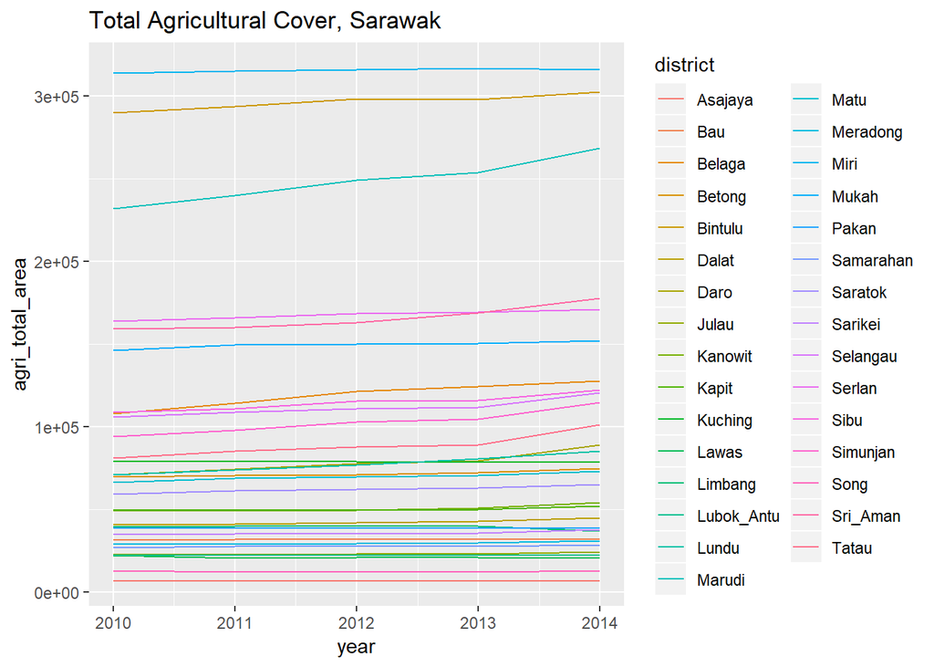

```r
#Total area
ggplot(data = swk, aes(x = year, y = agri_total_area, color = district)) +
  geom_line() +
  labs(title = 'Total Agricultural Cover, Sarawak')
```

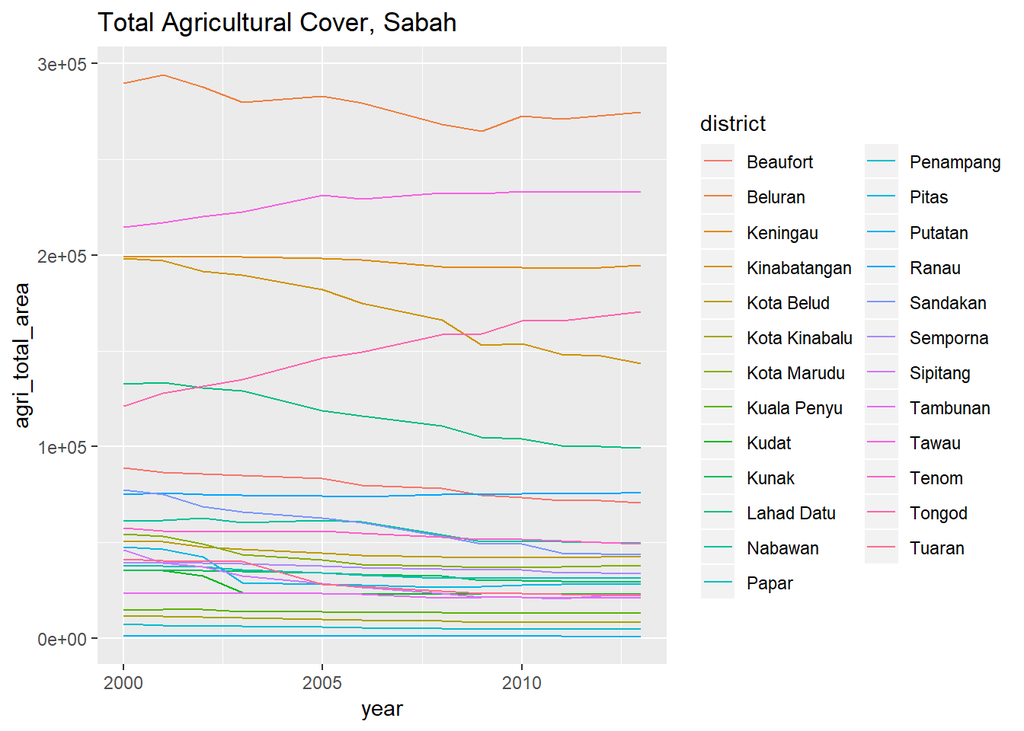

```r
ggplot(data = sbh, aes(x = year, y = agri_total_area, color = district)) +
  geom_line() +
  labs(title = 'Total Agricultural Cover, Sabah')
```

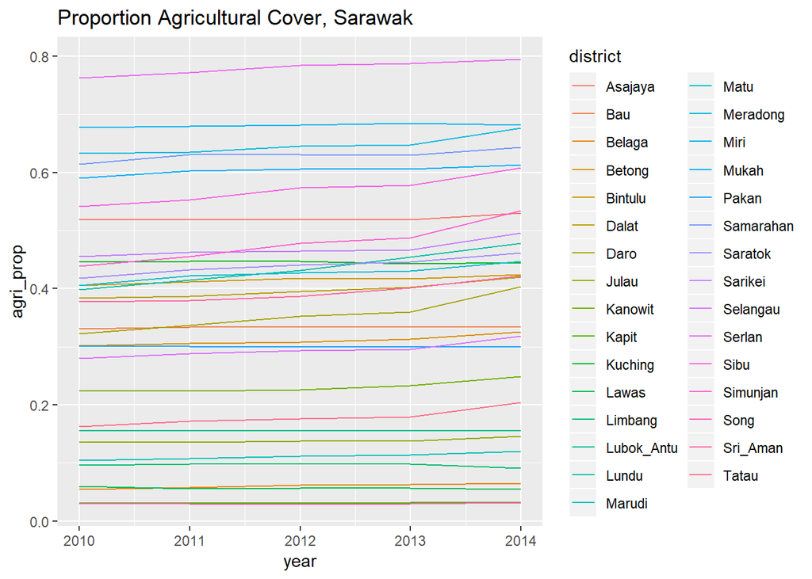

```r
#Proportion
ggplot(data = swk, aes(x = year, y = agri_prop, color = district)) +
  geom_line() +
  labs(title = 'Proportion Agricultural Cover, Sarawak')
```

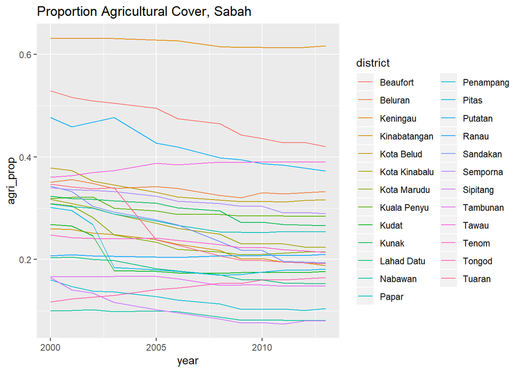

```r
ggplot(data = sbh, aes(x = year, y = agri_prop, color = district)) +
  geom_line() +
  labs(title = 'Proportion Agricultural Cover, Sabah')
```

### Correlations

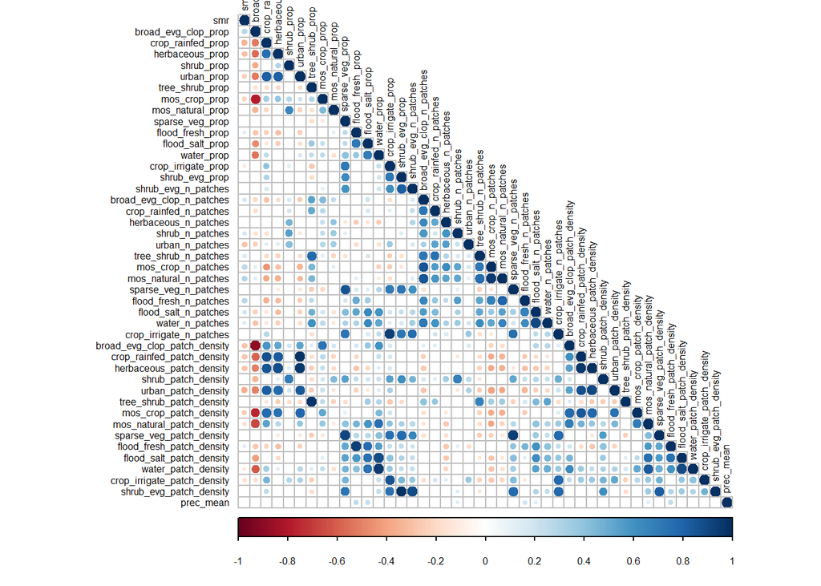

```r
res_sub <- rcorr(as.matrix(sbh_sub))

corrplot(res_sub$r, type = "lower",
        p.mat = res_sub$P, sig.level = 0.05, insig = "blank", tl.col = "black", tl.cex = 0.5, cl.cex = 0.5)
```

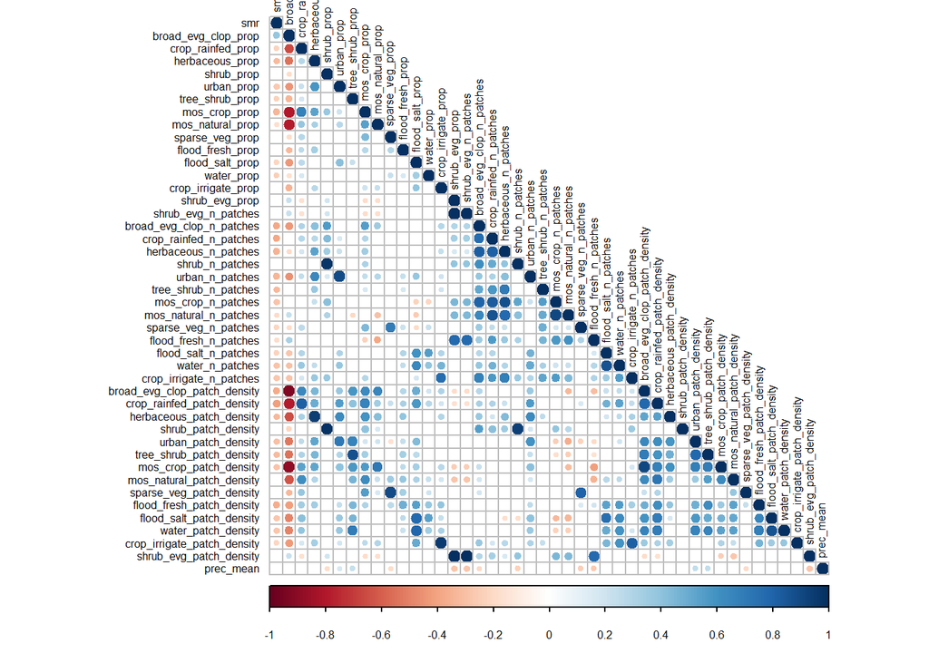

```r
res_sub2 <- rcorr(as.matrix(swk_sub))

corrplot(res_sub2$r, type = "lower",
        p.mat = res_sub2$P, sig.level = 0.05, insig = "blank", tl.col = "black", tl.cex = 0.5, cl.cex=0.5)
```

Take into account year

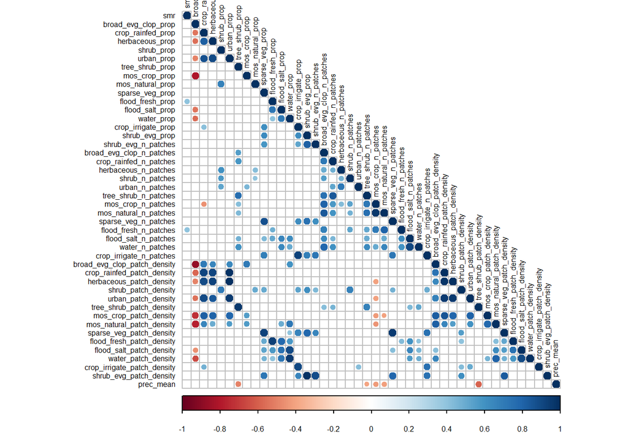

```r
sbh_sub_time = sbh %>%
  filter(year == 2000) %>%
  select(c("smr", "broad_evg_clop_prop", "crop_rainfed_prop", "herbaceous_prop", "shrub_prop", "urban_prop", "tree_shrub_prop", "mos_crop_prop", "mos_natural_prop", "sparse_veg_prop", "flood_fresh_prop", "flood_salt_prop", "water_prop", "crop_irrigate_prop", "shrub_evg_prop", "shrub_evg_n_patches", "broad_evg_clop_n_patches", "crop_rainfed_n_patches", "herbaceous_n_patches", "shrub_n_patches", "urban_n_patches", "tree_shrub_n_patches", "mos_crop_n_patches", "mos_natural_n_patches", "sparse_veg_n_patches", "flood_fresh_n_patches", "flood_salt_n_patches", "water_n_patches", "crop_irrigate_n_patches", "broad_evg_clop_patch_density","crop_rainfed_patch_density", "herbaceous_patch_density", "shrub_patch_density", "urban_patch_density", "tree_shrub_patch_density", "mos_crop_patch_density", "mos_natural_patch_density", "sparse_veg_patch_density", "flood_fresh_patch_density", "flood_salt_patch_density", "water_patch_density", "crop_irrigate_patch_density", "shrub_evg_patch_density", "prec_mean"))

res_sub_time = rcorr(as.matrix(sbh_sub_time))

corrplot(res_sub_time$r, type = "lower",
        p.mat = res_sub_time$P, sig.level = 0.05, insig = "blank", tl.col = "black", tl.cex = 0.5, cl.cex = 0.5)
```

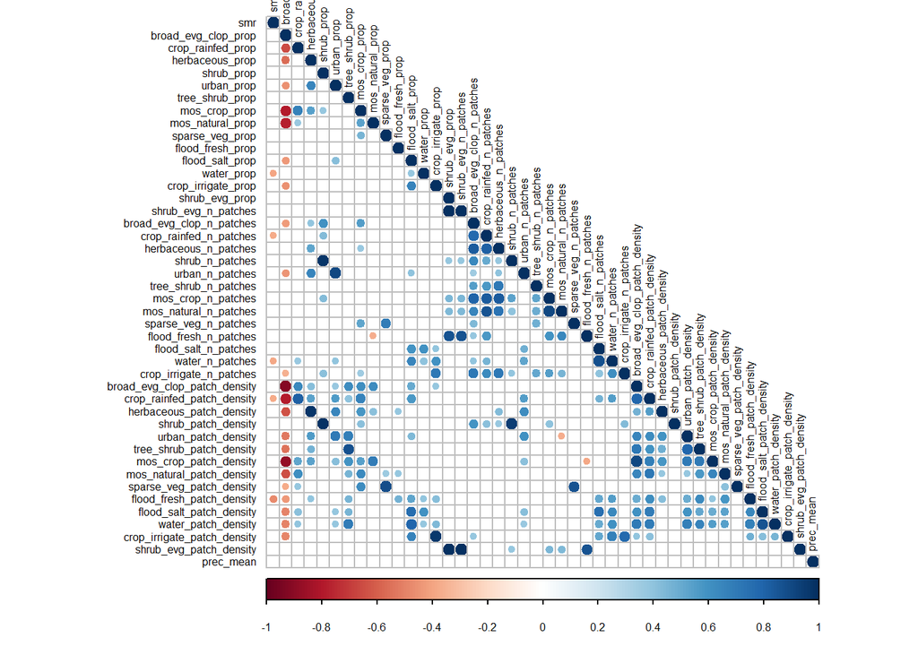

```r
swk_sub_time = swk %>%
  filter(year == 2010) %>%
  select(c("smr", "broad_evg_clop_prop", "crop_rainfed_prop", "herbaceous_prop", "shrub_prop", "urban_prop", "tree_shrub_prop", "mos_crop_prop", "mos_natural_prop", "sparse_veg_prop", "flood_fresh_prop", "flood_salt_prop", "water_prop", "crop_irrigate_prop", "shrub_evg_prop", "shrub_evg_n_patches", "broad_evg_clop_n_patches", "crop_rainfed_n_patches", "herbaceous_n_patches", "shrub_n_patches", "urban_n_patches", "tree_shrub_n_patches", "mos_crop_n_patches", "mos_natural_n_patches", "sparse_veg_n_patches", "flood_fresh_n_patches", "flood_salt_n_patches", "water_n_patches", "crop_irrigate_n_patches", "broad_evg_clop_patch_density","crop_rainfed_patch_density", "herbaceous_patch_density", "shrub_patch_density", "urban_patch_density", "tree_shrub_patch_density", "mos_crop_patch_density", "mos_natural_patch_density", "sparse_veg_patch_density", "flood_fresh_patch_density", "flood_salt_patch_density", "water_patch_density", "crop_irrigate_patch_density", "shrub_evg_patch_density", "prec_mean"))

res_sub_time2 = rcorr(as.matrix(swk_sub_time))

corrplot(res_sub_time2$r, type = "lower",
        p.mat = res_sub_time2$P, sig.level = 0.05, insig = "blank", tl.col = "black", tl.cex = 0.5, cl.cex = 0.5)
```